# **Assignment 2**

## Deconstruct, Reconstruct Web Report

### Tanish Saajan (s3940991)

**Introduction**

The World’s Billionaires list is an annual listing of the world’s wealthiest people conducted by Forbes, which calculates the net worth of individuals and ranks them accordingly. In 2020, Forbes ranked 2756 individuals in their final list of billionaires.

Click the **Original**, **Code** and **Reconstruction** tabs to read about the issues and how they were fixed.

#### Original

[figure not shown]

**Objective**:

The objective of this data visualization is to visually represent the name,net worth, country and the industry or source of wealth affiliations of the top 30 wealthiest individuals in the world in 2020. The chart is designed to provide insights into global wealth distribution and enables viewers to quickly compare the net worth of each individual.

**Target audience**:

This data visualization is intended for professionals in finance, economics, and related fields, including researchers, journalists, academics, investors, and business leaders. The chart may also be of interest to individuals seeking a deeper understanding of global wealth distribution, including students, policymakers, and the general public.

The selected visualization has three significant problems.

- **Visual Bombardment**: The info graphic tries to pack a lot of information into a single visual, which can make it difficult for viewers to process the data. In the case of this visualization if a viewer is trying to compare the net worth of two individuals, they can be overwhelmed by the sheer number of bubbles on the visualization, there are 30 individuals represented, each with different variables such as name, net worth,source of wealths,and country, making it difficult to focus on the specific data points of interest. This could lead to errors in interpretation or inaccurate conclusions being drawn from the data.Therefore, the visual can be overwhelming and may cause viewers to miss important information.
- **Deceptive method**: The use of inconsistent circle sizes to represent the net worth of individuals can be deceptive. For example, the circle representing Mark Zuckerberg’s net worth appears larger than the circle representing Bill Gates’ net worth, despite Bill Gates having a greater net worth. This inconsistency could potentially lead to misinterpretations of the data.Additionally, there is inconsistency in how the source of wealth is displayed. Some billionaires are marked with the company they own, while others are marked with the industry they are associated with. For instance, Jeff Bezos is marked with his company (Amazon), whereas all the people from Asia, such as Mukesh Ambani (Diversified) and Jack Ma (E-commerce), are marked with the industry they are in. This inconsistency could lead to confusion and inaccurate comparisons between individuals and industries, potentially leading to incorrect conclusions and misinterpretations of the data.
- **Poor Colour Coding**: The use of poor colour coding in this visualization can lead to confusion and inaccurate conclusions, especially when similar colors are used to represent different values. In this visualization, the colours used for representing net worth categories between $50B- $99.9B and less than $40B are very similar, which can make it difficult for the audience to differentiate between the two.

**Reference**

- HowMuch. (2020, April 15). Top 30 Richest Men in the World 2020. Retrieved from https://howmuch.net/articles/top-30-richest-men-in-the-world-2020

#### Code

```r
library(knitr)
library(ggplot2)
library(rmarkdown)
library(magrittr)
library(dplyr)
setwd("/Users/tanishsaajan/Documents/Data Visualisation/Assignment 2")
data<-read.csv("Billionaire.csv")
data<-head(data,15)
data<-data[,c("Name","NetWorth","Country","Industry")]
data$Industry <- factor(data$Industry)
data$NetWorth<- factor(data$NetWorth)
data$Country<-factor(data$Country)
```

```r
 p1 <- ggplot(data, aes(y = Industry, x = NetWorth, fill ="color")) +
    geom_bar(stat = "identity", position = position_dodge(width = 1.9), width = 0.5) +
  geom_col(aes(col = Industry), position = position_dodge(width = 50), color = "black", show.legend = FALSE)+
    geom_text(aes(label = Name),
              position = position_dodge(width = 0),
              hjust = -0.06, vjust = 0.3,
              size = 2.5, fontface = "bold")+
  scale_fill_manual(values = "#9CC5E9", guide = FALSE)+
     theme(

       axis.text = element_text(size = 7), axis.title = element_text(size = 15, face = "bold"),
          plot.title = element_text(size = 19, face = "bold"), plot.subtitle = element_text(size = 13),legend.position = "bottom",
          axis.text.x = element_text(face = "bold"),
          axis.text.y = element_text(face = "bold"),
          axis.title.x = element_text(face = "bold",vjust = -0.5),
          axis.title.y = element_text(face = "bold")) +

    labs(title = "Top 15 Richest Men in the World (2021)", subtitle = "Estimated Net Worth and Industry",
         x = "Net Worth in Billion Dollars", fill = "Country",caption = "Source:www.kaggle.com") +

    scale_y_discrete(name = "Industry of Achievement", expand = c(0, 1)) +

    coord_flip()
```

**Data Reference**

-RoySouravCU. (2021). Forbes Billionaires of 2021. Retrieved from https://www.kaggle.com/datasets/roysouravcu/forbes-billionaires-of-2021

#### Reconstruction

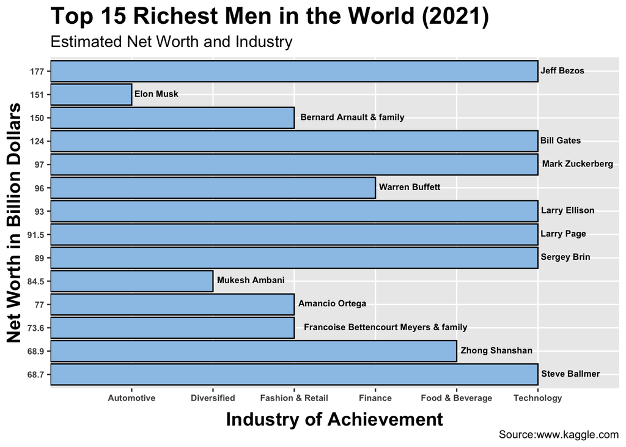